# R을 이용한 <모두의 말뭉치> 활용 기초 (2회차)

### 2회차에서 다루는 내용

- 한글 텍스트 파일의 인코딩(cp949, utf-8) 변환
- 문자열 검색 및 치환: 정규식 소개
- 모두의 말뭉치: 말뭉치 종류 - 일반 말뭉치, 특수 말뭉치, 장르 말뭉치 -> 목적에 맞는 말뭉치 선정 중요
- 모두의 말뭉치: 말뭉치의 구조 - 대표적 말뭉치의 json 구조

### 텍스트 파일의 인코딩

- 인코딩(character encoding): 언어의 문자를 컴퓨터가 처리할 수 있는 숫자와 기호 등의 부호로 바꾸는 것
- 한글 텍스트 파일에 적용되는 인코딩은 크게 cp949 (혹은 euc-kr)와 utf-8 등 두 가지
- 한글 윈도우 시스템은 cp949 인코딩을, mac과 Linux는 utf-8 인코딩을 기반으로 함
  - 한글 윈도우 시스템에서 utf-8으로 인코딩된 한글 텍스트 파일을 열었을 때 깨져 보이게 되는 이유
  - 다운로드한 텍스트 파일을 메모장 등으로 열었을 때 문자들이 다 깨져 보인다면 문자 인코딩 문제가 원인일 경우가 많음
- 인코딩 문제는 주로 한글 텍스트와 관련된 것으로 영어 텍스트는 컴퓨터 시스템에 따른 인코딩의 영향이 크지 않음

[figure not shown]

- utf-8으로 인코딩된 한글 텍스트를 윈도우 메모장으로 열면 위 화면처럼 문자들이 깨져 보인다.
- 이 파일을 notepad++ 에디터로 열면 정상적으로 열리고, 제일 하단에 이 파일의 인코딩 정보를 UTF-8으로 보여준다.
- 이 파일은 Encoding 메뉴에서 Convert to ANSI를 선택한 후 ‘다른 이름으로 저장’ 메뉴에서 다른 이름으로 저장 후 윈도우 메모장에서 열면 정상적으로 열린다.

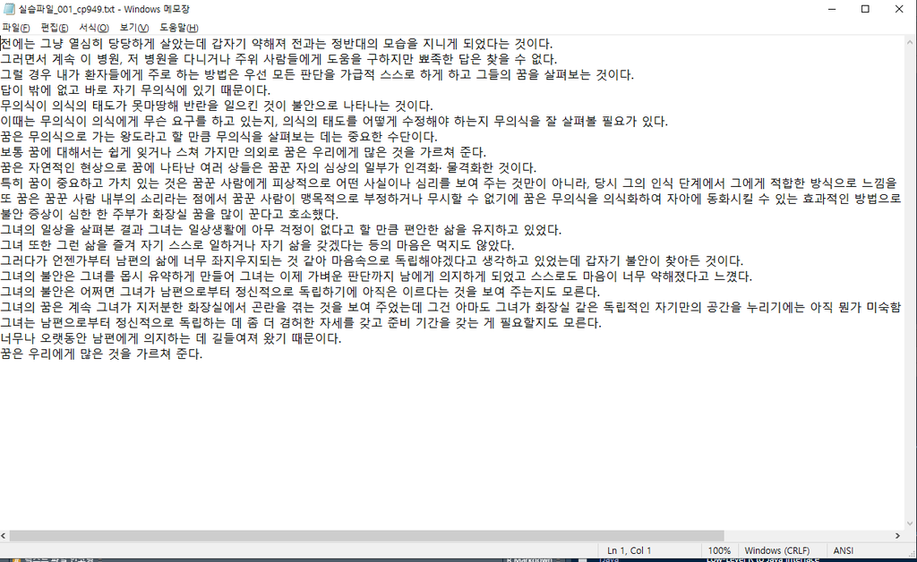

#### Rstudio의 기본 인코딩 설정

RStudio에서는 기본 인코딩을 변경 설정하는 기능이 있다. 이 기본 인코딩을 utf-8으로 설정하는 것을 추천한다. RStudio의 Tools 메뉴의 Global options 항목으로 들어간 후 Code > Saving 항목으로 간 후에 default text encoding을 utf-8으로 설정하고 저장한다.

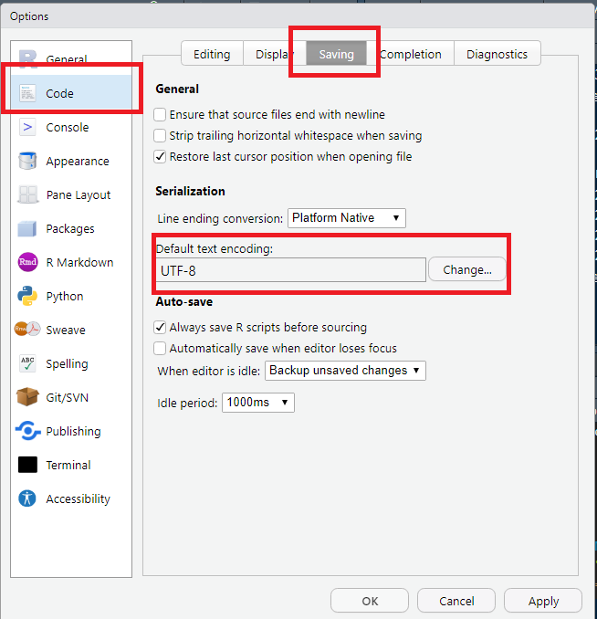

Rstudio 문자 인코딜 설정

설정 후 utf-8 인코딩 파일을 읽으면 제대로 읽힌다. (* 윈도우즈 시스템에 설치한 R에서는 간혹 한글 텍스트나 특수 문자 등을 읽을 때 깨지는 경우가 발생하는데 Rstudio를 사용하면 문제가 해결된다.)

윈도우즈 시스템에서 utf-8으로 인코딩된 파일을 정상적으로 읽을 수 있다.

```r
txt_path <- "data/실습파일/실습파일_001_utf-8.txt"
txt <- readLines(txt_path)

print(txt)
```

```
##  [1] "전에는 그냥 열심히 당당하게 살았는데 갑자기 약해져 전과는 정반대의 모습을 지니게 되었다는 것이다."
##  [2] "그러면서 계속 이 병원, 저 병원을 다니거나 주위 사람들에게 도움을 구하지만 뾰족한 답은 찾을 수 없다."
##  [3] "그럴 경우 내가 환자들에게 주로 하는 방법은 우선 모든 판단을 가급적 스스로 하게 하고 그들의 꿈을 살펴보는 것이다."
##  [4] "답이 밖에 없고 바로 자기 무의식에 있기 때문이다."
##  [5] "무의식이 의식의 태도가 못마땅해 반란을 일으킨 것이 불안으로 나타나는 것이다."
##  [6] "이때는 무의식이 의식에게 무슨 요구를 하고 있는지, 의식의 태도를 어떻게 수정해야 하는지 무의식을 잘 살펴볼 필요가 있다."
##  [7] "꿈은 무의식으로 가는 왕도라고 할 만큼 무의식을 살펴보는 데는 중요한 수단이다."
##  [8] "보통 꿈에 대해서는 쉽게 잊거나 스쳐 가지만 의외로 꿈은 우리에게 많은 것을 가르쳐 준다."
##  [9] "꿈은 자연적인 현상으로 꿈에 나타난 여러 상들은 꿈꾼 자의 심상의 일부가 인격화· 물격화한 것이다."
## [10] "특히 꿈이 중요하고 가치 있는 것은 꿈꾼 사람에게 피상적으로 어떤 사실이나 심리를 보여 주는 것만이 아니라, 당시 그의 인식 단계에서 그에게 적합한 방식으로 느낌을 움직여 그의 정신을 자극한다는 점이다."
## [11] "또 꿈은 꿈꾼 사람 내부의 소리라는 점에서 꿈꾼 사람이 맹목적으로 부정하거나 무시할 수 없기에 꿈은 무의식을 의식화하여 자아에 동화시킬 수 있는 효과적인 방법으로 이해되어 왔다."
## [12] "불안 증상이 심한 한 주부가 화장실 꿈을 많이 꾼다고 호소했다."
## [13] "그녀의 일상을 살펴본 결과 그녀는 일상생활에 아무 걱정이 없다고 할 만큼 편안한 삶을 유지하고 있었다."
## [14] "그녀 또한 그런 삶을 즐겨 자기 스스로 일하거나 자기 삶을 갖겠다는 등의 마음은 먹지도 않았다."
## [15] "그러다가 언젠가부터 남편의 삶에 너무 좌지우지되는 것 같아 마음속으로 독립해야겠다고 생각하고 있었는데 갑자기 불안이 찾아든 것이다."
## [16] "그녀의 불안은 그녀를 몹시 유약하게 만들어 그녀는 이제 가벼운 판단까지 남에게 의지하게 되었고 스스로도 마음이 너무 약해졌다고 느꼈다."
## [17] "그녀의 불안은 어쩌면 그녀가 남편으로부터 정신적으로 독립하기에 아직은 이르다는 것을 보여 주는지도 모른다."
## [18] "그녀의 꿈은 계속 그녀가 지저분한 화장실에서 곤란을 겪는 것을 보여 주었는데 그건 아마도 그녀가 화장실 같은 독립적인 자기만의 공간을 누리기에는 아직 뭔가 미숙함을 의미하는지도 모른다."
## [19] "그녀는 남편으로부터 정신적으로 독립하는 데 좀 더 겸허한 자세를 갖고 준비 기간을 갖는 게 필요할지도 모른다."
## [20] "너무나 오랫동안 남편에게 의지하는 데 길들여져 왔기 때문이다."
## [21] "꿈은 우리에게 많은 것을 가르쳐 준다."
```

- 라인 1: 대상 텍스트 파일의 위치 경로를 txt_path 변수에 저장한다.
- 라인 2: 텍스트 파일을 통째로 읽는 readLines() 함수를 사용하여 읽어들인다.

cp949로 인코딩된 파일을 읽었을 때는 글자들이 깨진다.

```r
txt_path <- "data/실습파일/실습파일_001_CP949.txt"
txt <- readLines(txt_path)

print(txt)
```

```
##  [1] "\xc0\xfc\xbf\xa1\xb4\xc2 \xb1׳\xc9 \xbf\xad\xbd\xc9\xc8\xf7 \xb4\xe7\xb4\xe7\xc7ϰ\xd4 \xbb\xec\xbeҴµ\xa5 \xb0\xa9\xc0ڱ\xe2 \xbe\xe0\xc7\xd8\xc1\xae \xc0\xfc\xb0\xfa\xb4\xc2 \xc1\xa4\xb9ݴ\xeb\xc0\xc7 \xb8\xf0\xbd\xc0\xc0\xbb \xc1\xf6\xb4ϰ\xd4 \xb5Ǿ\xfa\xb4ٴ\xc2 \xb0\xcd\xc0̴\xd9."
##  [2] "\xb1\u05f7\xaf\xb8鼭 \xb0\xe8\xbc\xd3 \xc0\xcc \xba\xb4\xbf\xf8, \xc0\xfa \xba\xb4\xbf\xf8\xc0\xbb \xb4ٴϰų\xaa \xc1\xd6\xc0\xa7 \xbb\xe7\xb6\xf7\xb5鿡\xb0\xd4 \xb5\xb5\xbf\xf2\xc0\xbb \xb1\xb8\xc7\xcf\xc1\xf6\xb8\xb8 \xbb\xcf\xc1\xb7\xc7\xd1 \xb4\xe4\xc0\xba ã\xc0\xbb \xbc\xf6 \xbe\xf8\xb4\xd…
##  [3] "\xb1\u05f7\xb2 \xb0\xe6\xbf\xec \xb3\xbb\xb0\xa1 ȯ\xc0ڵ鿡\xb0\xd4 \xc1ַ\xce \xc7ϴ\xc2 \xb9\xe6\xb9\xfd\xc0\xba \xbf켱 \xb8\xf0\xb5\xe7 \xc6Ǵ\xdc\xc0\xbb \xb0\xa1\xb1\xde\xc0\xfb \xbd\xba\xbd\xba\xb7\xce \xc7ϰ\xd4 \xc7ϰ\xed \xb1\u05f5\xe9\xc0\xc7 \xb2\xde\xc0\xbb \xbb\xec\xc6캸\xb4\xc2 \xb0\xcd…
##  [4] "\xb4\xe4\xc0\xcc \xb9ۿ\xa1 \xbe\xf8\xb0\xed \xb9ٷ\xce \xc0ڱ\xe2 \xb9\xab\xc0ǽĿ\xa1 \xc0ֱ\xe2 \xb6\xa7\xb9\xae\xc0̴\xd9."
##  [5] "\xb9\xab\xc0ǽ\xc4\xc0\xcc \xc0ǽ\xc4\xc0\xc7 \xc5µ\xb5\xb0\xa1 \xb8\xf8\xb8\xb6\xb6\xa5\xc7\xd8 \xb9ݶ\xf5\xc0\xbb \xc0\xcf\xc0\xb8Ų \xb0\xcd\xc0\xcc \xbaҾ\xc8\xc0\xb8\xb7\xce \xb3\xaaŸ\xb3\xaa\xb4\xc2 \xb0\xcd\xc0̴\xd9."
##  [6] "\xc0̶\xa7\xb4\xc2 \xb9\xab\xc0ǽ\xc4\xc0\xcc \xc0ǽĿ\xa1\xb0\xd4 \xb9\xab\xbd\xbc \xbf䱸\xb8\xa6 \xc7ϰ\xed \xc0ִ\xc2\xc1\xf6, \xc0ǽ\xc4\xc0\xc7 \xc5µ\xb5\xb8\xa6 \xbe\xb0\xd4 \xbc\xf6\xc1\xa4\xc7ؾ\xdf \xc7ϴ\xc2\xc1\xf6 \xb9\xab\xc0ǽ\xc4\xc0\xbb \xc0\xdf \xbb\xec\xc6캼 \xc7ʿ䰡 \xc0ִ\xd9."
##  [7] "\xb2\xde\xc0\xba \xb9\xab\xc0ǽ\xc4\xc0\xb8\xb7\xce \xb0\xa1\xb4\xc2 \xbfյ\xb5\xb6\xf3\xb0\xed \xc7\xd2 \xb8\xb8ŭ \xb9\xab\xc0ǽ\xc4\xc0\xbb \xbb\xec\xc6캸\xb4\xc2 \xb5\xa5\xb4\xc2 \xc1߿\xe4\xc7\xd1 \xbc\xf6\xb4\xdc\xc0̴\xd9."
##  [8] "\xba\xb8\xc5\xeb \xb2\u07bf\xa1 \xb4\xeb\xc7ؼ\xad\xb4\xc2 \xbd\xb1\xb0\xd4 \xc0ذų\xaa \xbd\xba\xc3\xc4 \xb0\xa1\xc1\xf6\xb8\xb8 \xc0ǿܷ\xce \xb2\xde\xc0\xba \xbf츮\xbf\xa1\xb0\xd4 \xb8\xb9\xc0\xba \xb0\xcd\xc0\xbb \xb0\xa1\xb8\xa3\xc3\xc4 \xc1ش\xd9."
##  [9] "\xb2\xde\xc0\xba \xc0ڿ\xac\xc0\xfb\xc0\xce \xc7\xf6\xbb\xf3\xc0\xb8\xb7\xce \xb2\u07bf\xa1 \xb3\xaaŸ\xb3\xad \xbf\xa9\xb7\xaf \xbb\xf3\xb5\xe9\xc0\xba \xb2\u07b2\xdb \xc0\xda\xc0\xc7 \xbdɻ\xf3\xc0\xc7 \xc0Ϻΰ\xa1 \xc0ΰ\xddȭ\xa1\xa4 \xb9\xb0\xb0\xddȭ\xc7\xd1 \xb0\xcd\xc0̴\xd9."
## [10] "Ư\xc8\xf7 \xb2\xde\xc0\xcc \xc1߿\xe4\xc7ϰ\xed \xb0\xa1ġ \xc0ִ\xc2 \xb0\xcd\xc0\xba \xb2\u07b2\xdb \xbb\xe7\xb6\xf7\xbf\xa1\xb0\xd4 \xc7ǻ\xf3\xc0\xfb\xc0\xb8\xb7\xce \xbe \xbb\xe7\xbd\xc7\xc0̳\xaa \xbdɸ\xae\xb8\xa6 \xba\xb8\xbf\xa9 \xc1ִ\xc2 \xb0\u0378\xb8\xc0\xcc \xbeƴ϶\xf3, \xb4\xe7\xbd\xc…
## [11] "\xb6\xc7 \xb2\xde\xc0\xba \xb2\u07b2\xdb \xbb\xe7\xb6\xf7 \xb3\xbb\xba\xce\xc0\xc7 \xbcҸ\xae\xb6\xf3\xb4\xc2 \xc1\xa1\xbf\xa1\xbc\xad \xb2\u07b2\xdb \xbb\xe7\xb6\xf7\xc0\xcc \xb8\u0378\xf1\xc0\xfb\xc0\xb8\xb7\xce \xba\xce\xc1\xa4\xc7ϰų\xaa \xb9\xab\xbd\xc3\xc7\xd2 \xbc\xf6 \xbe\xf8\xb1\u2fe…
## [12] "\xbaҾ\xc8 \xc1\xf5\xbb\xf3\xc0\xcc \xbd\xc9\xc7\xd1 \xc7\xd1 \xc1ֺΰ\xa1 ȭ\xc0\xe5\xbd\xc7 \xb2\xde\xc0\xbb \xb8\xb9\xc0\xcc \xb2۴ٰ\xed ȣ\xbc\xd2\xc7ߴ\xd9."
## [13] "\xb1׳\xe0\xc0\xc7 \xc0ϻ\xf3\xc0\xbb \xbb\xec\xc6캻 \xb0\xe1\xb0\xfa \xb1׳\xe0\xb4\xc2 \xc0ϻ\xf3\xbb\xfdȰ\xbf\xa1 \xbeƹ\xab \xb0\xc6\xc1\xa4\xc0\xcc \xbe\xf8\xb4ٰ\xed \xc7\xd2 \xb8\xb8ŭ \xc6\xed\xbe\xc8\xc7\xd1 \xbb\xee\xc0\xbb \xc0\xaf\xc1\xf6\xc7ϰ\xed \xc0־\xfa\xb4\xd9."
## [14] "\xb1׳\xe0 \xb6\xc7\xc7\xd1 \xb1\u05f7\xb1 \xbb\xee\xc0\xbb \xc1\xf1\xb0\xdc \xc0ڱ\xe2 \xbd\xba\xbd\xba\xb7\xce \xc0\xcf\xc7ϰų\xaa \xc0ڱ\xe2 \xbb\xee\xc0\xbb \xb0\xae\xb0ڴٴ\xc2 \xb5\xee\xc0\xc7 \xb8\xb6\xc0\xbd\xc0\xba \xb8\xd4\xc1\xf6\xb5\xb5 \xbeʾҴ\xd9."
## [15] "\xb1\u05f7\xaf\xb4ٰ\xa1 \xbe\xf0\xc1\xa8\xb0\xa1\xba\xce\xc5\xcd \xb3\xb2\xc6\xed\xc0\xc7 \xbb \xb3ʹ\xab \xc1\xc2\xc1\xf6\xbf\xec\xc1\xf6\xb5Ǵ\xc2 \xb0\xcd \xb0\xb0\xbe\xc6 \xb8\xb6\xc0\xbd\xbc\xd3\xc0\xb8\xb7\xce \xb5\xb6\xb8\xb3\xc7ؾ߰ڴٰ\xed \xbb\xfd\xb0\xa2\xc7ϰ\xed \xc0־\xfa\xb4µ\xa5 \xb…
## [16] "\xb1׳\xe0\xc0\xc7 \xbaҾ\xc8\xc0\xba \xb1׳ฦ \xb8\xf7\xbd\xc3 \xc0\xaf\xbe\xe0\xc7ϰ\xd4 \xb8\xb8\xb5\xe9\xbe\xee \xb1׳\xe0\xb4\xc2 \xc0\xcc\xc1\xa6 \xb0\xa1\xba\xad\xbf\xee \xc6Ǵܱ\xee\xc1\xf6 \xb3\xb2\xbf\xa1\xb0\xd4 \xc0\xc7\xc1\xf6\xc7ϰ\xd4 \xb5Ǿ\xfa\xb0\xed \xbd\xba\xbd\xba\xb7ε\xb5 \xb8\x…
## [17] "\xb1׳\xe0\xc0\xc7 \xbaҾ\xc8\xc0\xba \xbe\xee¼\xb8\xe9 \xb1׳డ \xb3\xb2\xc6\xed\xc0\xb8\xb7κ\xce\xc5\xcd \xc1\xa4\xbd\xc5\xc0\xfb\xc0\xb8\xb7\xce \xb5\xb6\xb8\xb3\xc7ϱ\u2fe1 \xbe\xc6\xc1\xf7\xc0\xba \xc0̸\xa3\xb4ٴ\xc2 \xb0\xcd\xc0\xbb \xba\xb8\xbf\xa9 \xc1ִ\xc2\xc1\xf6\xb5\xb5 \xb8𸥴\xd9."
## [18] "\xb1׳\xe0\xc0\xc7 \xb2\xde\xc0\xba \xb0\xe8\xbc\xd3 \xb1׳డ \xc1\xf6\xc0\xfa\xba\xd0\xc7\xd1 ȭ\xc0\xe5\xbdǿ\xa1\xbc\xad \xb0\xef\xb6\xf5\xc0\xbb \xb0\u07b4\xc2 \xb0\xcd\xc0\xbb \xba\xb8\xbf\xa9 \xc1־\xfa\xb4µ\xa5 \xb1װ\xc7 \xbeƸ\xb6\xb5\xb5 \xb1׳డ ȭ\xc0\xe5\xbd\xc7 \xb0\xb0\xc0\xba \xb5\xb6\…
## [19] "\xb1׳\xe0\xb4\xc2 \xb3\xb2\xc6\xed\xc0\xb8\xb7κ\xce\xc5\xcd \xc1\xa4\xbd\xc5\xc0\xfb\xc0\xb8\xb7\xce \xb5\xb6\xb8\xb3\xc7ϴ\xc2 \xb5\xa5 \xc1\xbb \xb4\xf5 \xb0\xe2\xc7\xe3\xc7\xd1 \xc0ڼ\xbc\xb8\xa6 \xb0\xae\xb0\xed \xc1غ\xf1 \xb1Ⱓ\xc0\xbb \xb0\xae\xb4\xc2 \xb0\xd4 \xc7ʿ\xe4\xc7\xd2\xc1\xf6\x…
## [20] "\xb3ʹ\xab\xb3\xaa \xbf\xc0\xb7\xa7\xb5\xbf\xbe\xc8 \xb3\xb2\xc6\xed\xbf\xa1\xb0\xd4 \xc0\xc7\xc1\xf6\xc7ϴ\xc2 \xb5\xa5 \xb1\xe6\xb5鿩\xc1\xae \xbfԱ\xe2 \xb6\xa7\xb9\xae\xc0̴\xd9."
## [21] "\xb2\xde\xc0\xba \xbf츮\xbf\xa1\xb0\xd4 \xb8\xb9\xc0\xba \xb0\xcd\xc0\xbb \xb0\xa1\xb8\xa3\xc3\xc4 \xc1ش\xd9."
```

#### iconv를 이용한 인코딩 변환

notepad++를 이용하여 인코딩을 utf-8으로 변환 후 다시 저장하는 방법도 있으나 R에서 바로 처리할 수도 있다.

```r
txt_path <- "data/실습파일/실습파일_001_CP949.txt"
txt <- readLines(txt_path)
txt_converted <- iconv(x= txt, from = "cp949", "utf-8")

print(txt[1:3]); print(txt_converted[1:3])
```

```
## [1] "\xc0\xfc\xbf\xa1\xb4\xc2 \xb1׳\xc9 \xbf\xad\xbd\xc9\xc8\xf7 \xb4\xe7\xb4\xe7\xc7ϰ\xd4 \xbb\xec\xbeҴµ\xa5 \xb0\xa9\xc0ڱ\xe2 \xbe\xe0\xc7\xd8\xc1\xae \xc0\xfc\xb0\xfa\xb4\xc2 \xc1\xa4\xb9ݴ\xeb\xc0\xc7 \xb8\xf0\xbd\xc0\xc0\xbb \xc1\xf6\xb4ϰ\xd4 \xb5Ǿ\xfa\xb4ٴ\xc2 \xb0\xcd\xc0̴\xd9."
## [2] "\xb1\u05f7\xaf\xb8鼭 \xb0\xe8\xbc\xd3 \xc0\xcc \xba\xb4\xbf\xf8, \xc0\xfa \xba\xb4\xbf\xf8\xc0\xbb \xb4ٴϰų\xaa \xc1\xd6\xc0\xa7 \xbb\xe7\xb6\xf7\xb5鿡\xb0\xd4 \xb5\xb5\xbf\xf2\xc0\xbb \xb1\xb8\xc7\xcf\xc1\xf6\xb8\xb8 \xbb\xcf\xc1\xb7\xc7\xd1 \xb4\xe4\xc0\xba ã\xc0\xbb \xbc\xf6 \xbe\xf8\xb4\xd9…
## [3] "\xb1\u05f7\xb2 \xb0\xe6\xbf\xec \xb3\xbb\xb0\xa1 ȯ\xc0ڵ鿡\xb0\xd4 \xc1ַ\xce \xc7ϴ\xc2 \xb9\xe6\xb9\xfd\xc0\xba \xbf켱 \xb8\xf0\xb5\xe7 \xc6Ǵ\xdc\xc0\xbb \xb0\xa1\xb1\xde\xc0\xfb \xbd\xba\xbd\xba\xb7\xce \xc7ϰ\xd4 \xc7ϰ\xed \xb1\u05f5\xe9\xc0\xc7 \xb2\xde\xc0\xbb \xbb\xec\xc6캸\xb4\xc2 \xb0\xcd\…
```

```
## [1] "전에는 그냥 열심히 당당하게 살았는데 갑자기 약해져 전과는 정반대의 모습을 지니게 되었다는 것이다."
## [2] "그러면서 계속 이 병원, 저 병원을 다니거나 주위 사람들에게 도움을 구하지만 뾰족한 답은 찾을 수 없다."
## [3] "그럴 경우 내가 환자들에게 주로 하는 방법은 우선 모든 판단을 가급적 스스로 하게 하고 그들의 꿈을 살펴보는 것이다."
```

- 라인 1: 대상 텍스트 파일의 위치 경로를 저장한다.
- 라인 2: 텍스트 파일을 통째로 읽는 readLines() 함수로 읽어들여 txt 변수에 할당한다.
- 라인 3: 읽어들인 텍스트 파일의 인코딩을 iconv() 함수를 이용하여 cp949에서 utf-8으로 변환하여 txt_converted 변수에 다시 저장한다.
- 라인 4: cp949 파일을 인코딩 변환없이 읽은 내용과 utf-8으로 인코딩 변환한 내용을 각각 3행씩 출력한다. 이 때는 []와 인덱스를 사용하여 출력할 라인을 지정한다.

### 텍스트 파일 전처리: 정규식(regular expressions)

- 정규식: 문자열의 검색과 치환을 위한 형식 언어이다. 텍스트 파일을 처리할 때 가장 많이 이용하는 작업 중 하나가 정규식을 이용한 문자열 검색과 문자열 찾기/바꾸기이다.
- 소수의 파일을 대상으로 고정된 형태의 문자열을 찾기/바꾸기하는 것은 워드프로세서로도 가능하지만 대량의 파일을 처리할 때는 워드프로세서로 처리하는 것이 쉽지 않다.
- 고정된 문자열이 아닌 가변형의 문자열은 정규식을 이용해야 한다.
- 정규식의 문법 체계와 활용 범위는 아주 방대하므로 여기서는 한글 말뭉치 텍스트를 다룰 때 가장 기본적인 것 몇 가지만 소개한다.
  - 보다 다양한 정규식 형태에 대한 설명은 https://www.regular-expressions.info/나 https://rstudio-pubs-static.s3.amazonaws.com/74603_76cd14d5983f47408fdf0b323550b846.html 등을 참고하면 된다.

#### 기본적인 정규식 패턴

| 정규식 패턴 | 의미 |
| --- | --- |
| [가나다] | ‘가’ 혹은 ‘나’ 혹은 ‘다’ 검색 |
| [0-9] | 숫자 0에서 9까지 전체 검색 |
| [a-zA-Z] | 알파벳 소문자 a에서 z까지, 대문자 A에서 Z까지 전체 검색 |
| [가-힣ㄱ-ㅎㅏ-ㅡ] | 한글 문자 ‘가’에서 ’힣’(가, 각, 갂, …, 힡, 힢, 힣), 자음 ‘ㄱ’에서 ’ㅎ’, 모음 ’ㅏ’에서 ’ㅡ’까지 전체 검색 |
| [a-zA-Z0-9] | 알파벳 소문자 a에서 z까지, 대문자 A에서 Z까지, 숫자 0에서 9까지 검색 |

#### 정규식을 이용한 문자열의 검색과 치환

R에서 정규식을 이용한 문자열 찾기는 **grep()**, 문자열 치환은 **gsub()** 함수를 사용한다.

##### 문자열 검색하기

**grep()** 함수는 찾고자 하는 문자열 패턴이 위치한 요소의 위치값을 반환한다.

```r
sents <- c("Social worker: Great. Did you bring it with you?", "사회복지사: 잘 하셨어요. 일기 가지고 오셨나요?", "Joker: (dodging the subject) I'm sorry. Did I bring what?", "조커: (못 들은 체하며) 죄송합니다. 뭐라고 하셨죠?")

print(sents)
```

```
## [1] "Social worker: Great. Did you bring it with you?"
## [2] "사회복지사: 잘 하셨어요. 일기 가지고 오셨나요?"
## [3] "Joker: (dodging the subject) I'm sorry. Did I bring what?"
## [4] "조커: (못 들은 체하며) 죄송합니다. 뭐라고 하셨죠?"
```

- 라인 1: sents라는 변수를 설정 후 총 4개의 문장(영어/한국어 대사)을 할당한다. 하나 이상의 요소를 변수에 할당할 때에는 c() 함수를 사용한다.
- 라인 2: sents 변수 내용을 출력한다.

```r
eng <- grep(pattern = "[a-zA-Z]", x = sents)
kor <- grep(pattern = "[가-힣ㄱ-ㅎㅏ-ㅡ]", x = sents)

print(eng); print(kor)
```

```
## [1] 1 3
```

```
## [1] 2 4
```

- 라인 1: 영문자가 하나라도 들어있는 대사의 위치를 찾아 *eng* 변수에 할당한다. 원하는 문자열의 정규식 패턴을 **pattern** 인자에 넣고, 찾는 대상인 문장이나 문서는 **x** 인자에 넣는다.
- 라인 2: 한글 문자가 하나라도 들어있는 대사의 위치를 찾아 *kor* 변수에 할당한다.
- 라인 4: *eng*, *kor*을 각각 출력한다.

문장을 어절 단위로 분리한 후 어절들에 대해 **grep()**을 사용할 수도 있다.

```r
eojeols1 <- strsplit(x = sents, split = " ")
eojeols2 <- unlist(eojeols1)

print(eojeols1); print(eojeols2)
```

```
## [[1]]
## [1] "Social"  "worker:" "Great."  "Did"     "you"     "bring"   "it"
## [8] "with"    "you?"
##
## [[2]]
## [1] "사회복지사:" "잘"          "하셨어요."   "일기"        "가지고"
## [6] "오셨나요?"
##
## [[3]]
##  [1] "Joker:"   "(dodging" "the"      "subject)" "I'm"      "sorry."
##  [7] "Did"      "I"        "bring"    "what?"
##
## [[4]]
## [1] "조커:"       "(못"         "들은"        "체하며)"     "죄송합니다."
## [6] "뭐라고"      "하셨죠?"
```

```
##  [1] "Social"      "worker:"     "Great."      "Did"         "you"
##  [6] "bring"       "it"          "with"        "you?"        "사회복지사:"
## [11] "잘"          "하셨어요."   "일기"        "가지고"      "오셨나요?"
## [16] "Joker:"      "(dodging"    "the"         "subject)"    "I'm"
## [21] "sorry."      "Did"         "I"           "bring"       "what?"
## [26] "조커:"       "(못"         "들은"        "체하며)"     "죄송합니다."
## [31] "뭐라고"      "하셨죠?"
```

- 라인 1: 문자열을 지정된 구분자(split 인자)에 따라 분리하는 strsplit() 함수를 이용하여 각 대사를 단어/어절로 분리한다. 즉 *sents* 변수에 저장된 4개 대사를 공백(즉 띄어쓰기, **split = ” “**) 기준으로 단어/어절 단위로 분리하여 *eojeols1* 변수에 할당한다. **strsplit()** 함수는 주어진 문자열 각각에 작동한다. 즉 4개의 대사 각각에 대해 단어/어절 분리를 하여 4개의 결과값으로 저장한다. 이러한 이중 구조 형태의 데이터 형식을 ’리스트(list)’라고 한다.
- 라인 2: **strsplit()** 함수에 의해 반환된 리스트 변수 *eojeols1*의 이중 구조를 **unlist()** 함수로 단일 구조로 푼 후 변수 *eojeols2*에 할당한다.
- 라인 4: *eojeols1*과 *eojeols2*를 각각 출력한다.

```r
x <- grep(pattern = "er", x = eojeols2)
y <- grep(pattern = "어요|나요|니다", eojeols2)
x_values <- eojeols2[x]
y_values <- eojeols2[y]

print(x); print(y); print(x_values); print(y_values)
```

```
## [1]  2 16
```

```
## [1] 12 15 30
```

```
## [1] "worker:" "Joker:"
```

```
## [1] "하셨어요."   "오셨나요?"   "죄송합니다."
```

```r
z <- grep(":|\\.|\\?", eojeols2)
zz <- grep("\\(|\\)", eojeols2)
print(z); print(zz)
```

```
##  [1]  2  3  9 10 12 15 16 21 25 26 30 32
```

```
## [1] 17 19 27 29
```

- 라인 1: *eojeols2*에서 콜론(:), 마침표(.), 물음표(?)가 있는 요소를 찾아 위치값을 *z*에 할당한다. 이 때 마침표와 물음표는 정규식에서 특수한 의미를 가진 특수 문자(메타문자)이므로 이 특수 문자와 문자 자체인 마침표/물음표를 구분해 주기 위해 escape 문자 ’\’를 앞에 붙인다.
- 라인 2: *eojeols2*에서 여는 괄호(()와 닫는 괄호())가 있는 요소를 찾아 위치값을 *zz*에 할당한다. 이 작은 괄호도 메타문자이므로 문자 자체인 여닫는 괄호와 구분하기 위해 escape 문자 ’\’를 붙인다.
- 라인 3: *z*와 *zz*를 각각 출력한다.

###### 메타 문자

메타 문자는 정규식에서 특수한 의미를 가지는 문자 집합으로 일반적인 텍스트 내의 문자와는 다른 의미를 가진다. 메타 문자를 일반 문자 자체로 인식하려면 해당 문자 앞에 ’\’를 붙여야 한다. 메타 문자의 종류에는 다음과 같은 것들이 있다.

. ^ $ * + ? { } [ ] | ( )

메타 문자를 비롯하여 정규식에 대한 보다 자세한 설명과 예시는 앞서 소개한 사이트들이나 인터넷 검색 등을 통해 찾아볼 수 있다.

###### strsplit()의 응용

strsplit()이 반환하는 리스트 구조를 이용하면 여러 문장 혹은 문서들의 길이 정보를 한번에 쉽게 구할 수 있다.

```r
splitted <- strsplit(x = sents, split = " ")

num_words <- c()

for (sent in splitted) {
  num <- length(sent)
  num_words <- c(num_words, num)
}

print(num_words)
```

```
## [1]  9  6 10  7
```

- 라인 1: 변수 sents에 저장된 4개의 대사를 strsplit() 함수로 각각 단어/어절로 분리하여 변수 splitted에 할당한다.
- 라인 3: 각 대사의 길이값을 할당할 변수 num_words를 생성한다. 이 변수는 for 문을 통해 반환된는 결과값을 담는 그릇 역할을 한다. 빈 변수는 c()로 생성한다.
- 라인 5, 8: for 문을 이용하여 splitted에 저장된 값(strsplit에 의해 분리된 대사)을 하나씩 차례대로 불러와서 sent라는 변수에 할당한다.
- 라인 6: 변수 sent에 저장된 단어/어절의 수를 세어 변수 num에 저장한다. 갯수를 세는 함수가 length()이다.
- 라인 7: 변수 num을 라인 3에서 생성한 변수에 집어넣는다. c()에서 첫 번째 인자 num_words는 새로운 값이 추가되는 변수이고, 두 번째 인자 num은 추가할 새로운 값이다. c() 함수는 값들을 차례대로 추가할 때 사용한다.
- 라인 10: 변수 num_words를 출력한다.

##### 문자열 치환

**gsub()** 함수는 특정 문자열을 찾아 그 문자열을 다른 문자열로 바꿀 때 사용한다.

```r
sents <- c("Social worker: Great. Did you bring it with you?", "사회복지사: 잘 하셨어요. 일기 가지고 오셨나요?", "Joker: (dodging the subject) I'm sorry. Did I bring what?", "조커: (못 들은 체하며) 죄송합니다. 뭐라고 하셨죠?")
sents_alpha_removed <- gsub(pattern = "[a-zA-Z]", replacement = "", x = sents)

print(sents_alpha_removed)
```

```
## [1] " : .      ?"
## [2] "사회복지사: 잘 하셨어요. 일기 가지고 오셨나요?"
## [3] ": (  ) ' .    ?"
## [4] "조커: (못 들은 체하며) 죄송합니다. 뭐라고 하셨죠?"
```

- 라인 1: *sents* 변수에 4개 대사를 할당한다.
- 라인 2: 모든 영문자를 정규식 패턴 ’[a-zA-Z]’으로 찾은 후 모두 공백(““)으로 바꾼다. 즉 모든 영문자를 삭제한다. 찾는 패턴은 **pattern** 인자에, 목표로 하는 패턴은 **replacement** 인자에 넣는다. 대상이 되는 문서는 **x** 인자에 넣는다. 바꾼 결과물을 변수 *sents_alpha_removed*에 할당한다.
- 라인 3: 변수 *sents_alpha_removed*를 출력한다.

영문자들이 삭제되고 남은 공백(스페이스)들이 남아 있으므로 남아있는 공백을 삭제하는 과정을 한번 더 거친다(공백도 하나의 문자로 취급).

```r
sents_alpha_removed_cleaned <- gsub(pattern = " +", replacement = "", x = sents_alpha_removed)
print(sents_alpha_removed_cleaned)
```

```
## [1] ":.?"
## [2] "사회복지사:잘하셨어요.일기가지고오셨나요?"
## [3] ":()'.?"
## [4] "조커:(못들은체하며)죄송합니다.뭐라고하셨죠?"
```

- 라인 1: 일반적인 공백도 문자로 취급되므로 **pattern** 인자에 ” “와 같이 기입한다. 공백이 하나 이상이므로 메타 문자인”+“를 공백 바로 다음에 붙인다.” +“는”하나 또는 하나 이상의 공백”이라는 의미이다. **replacement**에 ““를 주어 공백 문자를 삭제한다.
- 라인 2: *sents_alpha_removed_cleaned*를 출력한다.

괄호 속의 글자들을 괄호와 함께 모두 삭제할 수도 있다.

```r
sents_paren_removed <- gsub(pattern = "\\(.*\\)", replacement = "", x = sents)
print(sents_paren_removed)
```

```
## [1] "Social worker: Great. Did you bring it with you?"
## [2] "사회복지사: 잘 하셨어요. 일기 가지고 오셨나요?"
## [3] "Joker:  I'm sorry. Did I bring what?"
## [4] "조커:  죄송합니다. 뭐라고 하셨죠?"
```

- 라인 1: 여닫는 괄호는 모두 메타 문자이므로 괄호 문자 자체로 사용하려면 escape 문자 “\”를 바로 앞에 붙여준다. “\(”는 여는 괄호, “\)”는 닫는 괄호를 의미한다. 괄호 내의 “.*”는 아무 문자나 0개 또는 0개 이상을 의미한다. 즉 괄호 속에의 글자들을 의미한다.
- 라인 2: *sents_paren_removed*를 출력한다.

대사 내의 각 단어/어절에서 구두점을 한번에 모두 없앨 수도 있다.

```r
eojeols <- strsplit(x = sents, split = " ")
eojeols <- unlist(eojeols)
eojeols_punct_removed <- gsub(pattern = "[[:punct:]]", replacement = "", x = eojeols)

print(eojeols_punct_removed)
```

```
##  [1] "Social"     "worker"     "Great"      "Did"        "you"
##  [6] "bring"      "it"         "with"       "you"        "사회복지사"
## [11] "잘"         "하셨어요"   "일기"       "가지고"     "오셨나요"
## [16] "Joker"      "dodging"    "the"        "subject"    "Im"
## [21] "sorry"      "Did"        "I"          "bring"      "what"
## [26] "조커"       "못"         "들은"       "체하며"     "죄송합니다"
## [31] "뭐라고"     "하셨죠"
```

- 라인 1: *sents* 내의 4개 대사를 각각 단어/어절로 분리한다.
- 라인 2: 분리된 4개 대사를 하나의 단일 구조로 풀어준다.
- 라인 3: 단어/어절 전체에서 괄호를 포함한 모든 구두점을 찾아 삭제하고 *eojeols_punct_removed*에 할당한다. 모든 구두점은 문자 집합인 “[[:punct:]]”로 표현할 수 있다. **pattern* = “\.|\!|\?”과 같이 원하는 구두점만 찾아 삭제할 수도 있다.
- 라인 5: *eojeols_punct_removed*를 출력한다.

### 모두의 말뭉치

https://corpus.korean.go.kr/

현재 총 32건의 말뭉치가 제공되고 있으며, 말뭉치의 종류별로 구분해 보면 다음과 같다.

- 범용(일반) 말뭉치: 여러 장르와 텍스트 유형을 담고 있어 일반적인 언어학적 지식이나 증거를 추출 (예: 문어 말뭉치, 구어 말뭉치, 형태 분석 말뭉치)
- 특수 말뭉치: 특수한 한두 장르의 텍스트 유형을 담고 있으며, 해당 장르에 특수한 언어학적 지식이나 증거를 추출 (예: 신문 말뭉치, 국회 회의록 말뭉치, 일상 대화 말뭉치)
- 문어 말뭉치: 글로 쓴 텍스트 유형을 담고 있는 말뭉치(예: 신문 말뭉치, 문어 말뭉치, 비출판물 말뭉치, 메신저 말뭉치)
- 구어 말뭉치: 말로 한 음성 언어를 텍스트로 변환한 말뭉치(예: 구어 말뭉치, 국회 회의록 말뭉치, 대화 말뭉치)
- 음성 말뭉치: 음성 언어를 텍스트로 변환하지 않고 음성 정보 그대로 담고 있는 말뭉치(예: 서울말 낭독체 발화 말뭉치)
- 원시 말뭉치: 텍스트/음성 정보에 언어학적 분석 정보를 부착하지 않고 원문을 그대로 담고 있는 말뭉치(예: 비출판물 말뭉치, 신문 말뭉치, 메신저 말뭉치, 온라인 대화 말뭉치)
- 분석 말뭉치: 텍스트/음성 정보에 언어학적 분석 정보를 부착한 말뭉치(예: 형태 분석 말뭉치, 개체명 분석 말뭉치, 의미역 분석 말뭉치)

제공되는 말뭉치를 이용하기 전에 각 말뭉치의 내용과 구조에 대한 정보를 파악하는 것이 좋다. 말뭉치의 내용과 말뭉치 파일의 구조에 대한 정보는 각 말뭉치의 설명 자료 파일을 참고한다.

본 강의에서는 언어학 연구에서 많이 사용하는 문어 말뭉치, 구어 말뭉치, 형태 분석 말뭉치 등 3개 말뭉치를 대상으로 실습을 한다.

##### 문어 말뭉치

총 20,188개의 파일을 가지고 있으며, 파일 이름의 체계는 다음과 같다.

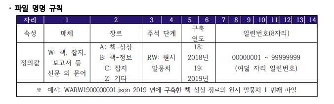

파일 이름이 규칙적이므로 전체 파일 중 특정 장르나 매체에 해당하는 파일들만 **grep()** 함수로 따로 골라낼 수도 있다.

파일의 형식은 json이다. json 형식은 xml 형식과 함께 말뭉치를 구축할 때 가장 많이 사용하는 표준 형식이다. json 파일의 기본 구조는 다음과 같다.

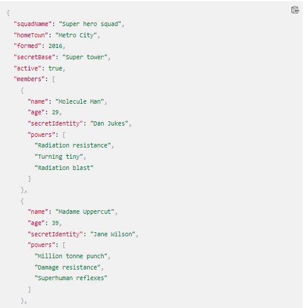

json은 {}로 둘러싸인 객체들로 구성되면 각 객체는 이름과 그 이름에 해당하는 값으로 구성되어 있다.

{“squadname”: “Super hero squad”}

이 객체들을 쌓아올려 하나의 json 파일을 만든다.

파일의 구조를 파악하려면 notepad++로 아무 파일이나 하나를 열어서 확인하면 된다.

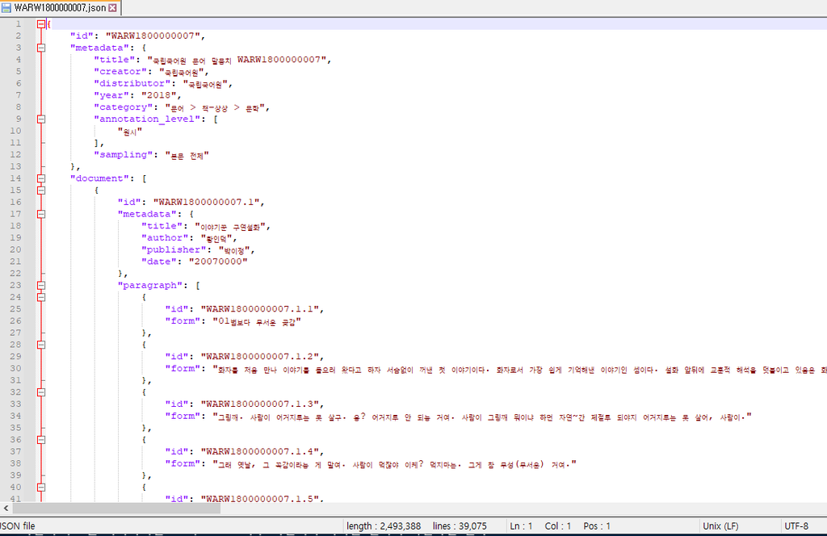

각 파일에는 id, metadata, document 등 세 개 요소가 최상위 객체이다. 에디터의 가장 좌측 라인 번호 옆의 네모 박스 안의 (-) 기호를 클릭하면 해당 객체에 속하는 하위 객체들이 숨김 처리된다. 숨김 처리를 하면 전체 구조를 손쉽게 파악할 수 있으며, 박스를 한번 더 클릭하면 숨김이 해제된다.

전체 구조는 다음과 같다.

- id: 파일 id
- metadata: 말뭉치의 정보(타이틀, 연도 등) 및 파일 전체의 정보(카테고리 등)
- document: 문서 객체
  - id: document의 id
  - metadata: document의 정보(제목, 저자 등)
  - paragraph: 문장, 문단
    - id: paragrpah의 id
    - form: paragraph의 내용(문장, 문단)

##### 구어 말뭉치

총 25,696개의 파일을 가지고 있으며, 파일 이름의 체계는 다음과 같다.

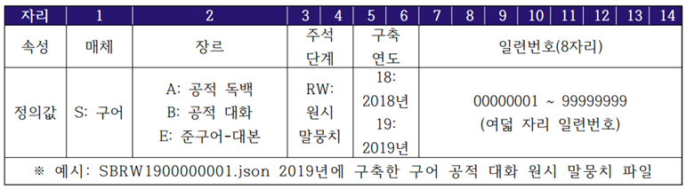

문어 말뭉치와 기본적으로 같은 구조를 가지고 있으나 발화자 정보가 추가되어 있다. 또한 구어와 준구어로 구분되어 있는데, 구어는 실제 발화한 내용을 글로 옮긴 것이고 준구어는 드라마 등의 대본 발화를 의미한다.

파일의 전체 구조는 다음과 같다.

- id: 파일 id
- metadata: 말뭉치의 정보(타이틀, 연도 등) 및 파일 전체의 정보(카테고리 등)
- document: 문서 객체
  - id: document의 id
  - metadata: document의 정보(제목, 발화자 정보 등)
    - speaker: 발화자의 기본 정보
  - utterance: 발화 내용
    - id: 발화 id
    - form: 정제한 발화 텍스트
    - original_form: 정제하기 전의 발화 텍스트

##### 일상 대화 말뭉치 2020

총 2,232개의 파일을 가지고 있으며, 파일 이름의 체계는 다음과 같다.

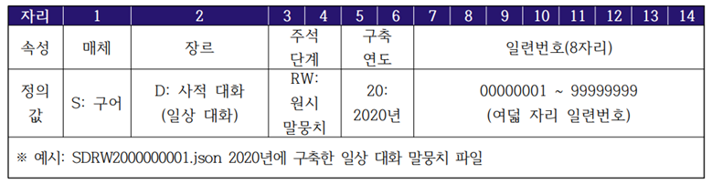

두 명의 발화자가 여러 주제에 대해 자유롭게 대화를 나눈 음성 자료를 텍스트로 옮긴 것이다.

파일의 전체 구조는 다음과 같다.

- id: 파일 id
- metadata: 말뭉치의 정보(타이틀, 연도 등) 및 파일 전체의 정보(카테고리 등)
- document: 문서 객체
  - id: document의 id
  - metadata: document의 정보(대화 주제, 발화자 정보 등)
    - speaker: 두 명의 발화자에 대한 두 개의 정보(각 발화자의 id 포함)
  - utterance: 발화 내용
    - id: 발화 id
    - form: 정제한 발화 텍스트
    - original_form: 정제하기 전의 발화 텍스트
    - speaker_id: 발화자 id

##### 온라인 대화 말뭉치

총 47,421개의 파일을 가지고 있으며, 파일 이름의 체계는 다음과 같다.

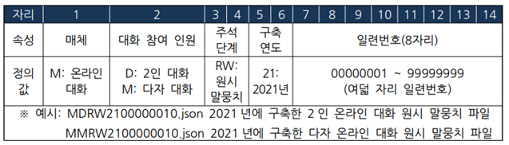

두 명 이상의 대화 참여자가 온라인상에서 주고 받은 대화를 수집한 것이다.

파일의 전체 구조는 다음과 같다.

- id: 파일 id
- metadata: 말뭉치의 정보(타이틀, 연도 등) 및 파일 전체의 정보(카테고리 등)
- document: 문서 객체
  - id: document의 id
  - metadata: document의 정보(대화 주제, 발화자 정보 등)
    - speaker: 대화 참여 발화자에 대한 각각의 정보(각 발화자의 id 포함)
  - utterance: 발화 내용
    - id: 발화 id
    - form: 정제한 발화 텍스트
    - original_form: 정제하기 전의 발화 텍스트
    - speaker_id: 발화자 id

##### 신문 말뭉치 (버전2.0)

총 364개의 파일로 구성되어 있으며, 파일 이름의 체계는 다음과 같다.

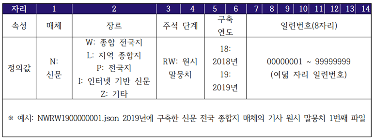

파일의 전체 구조는 다음과 같다.

- id: 파일 id
- metadata: 말뭉치의 정보(타이틀, 연도 등) 및 파일 전체의 정보(카테고리 등)
- document: 문서 객체
  - id: 개별 기사의 id
  - metadata: 개별 기사의 정보(신문명, 토픽, 날짜 등)
  - paragraph: 개별 기사 내용
    - id: 문장, 문단의 id
    - form: 문장, 문단의 내용

신문 말뭉치의 개별 파일에는 여러 개의 뉴스 기사가 같이 들어 있으며, 개별 기사는 두 번째 층위의 개별 기사 id로 구분된다.

##### 형태 분석 말뭉치

문어와 구어 각 1개씩 총 2개의 파일로 구성되어 있으며, 이름이 N으로 시작되는 파일이 문어, S로 시작되는 파일이 구어이다. 문어 200만, 구어 100만 어절에 대해 형태소 분석을 실행한 것이다.

파일의 전체 구조는 다음과 같다.

- id: 파일 id
- metadata: 말뭉치의 정보(타이틀, 연도 등) 및 파일 전체의 정보(카테고리 등)
- document: 문서 객체
  - id: 문장 id
  - form: 문장
  - word: 문장 내 어절
    - id: 어절 id
    - form: 어절
  - morpheme
    - id: 형태소 id
    - form: 형태소
    - label: 형태 분석 태그(품사)
    - word_id: 형태소가 속한 어절의 id